# Working with Web Tracking Data - Tutorial

Felix Schmidt

Maximilian Haag

2026-02-24

# Note

For the most up-to-date version of this tutorial, check [its repository on GitHub](https://github.com/ghxm/webtracking-data-tutorial).

# Setup and Prerequisites

For this tutorial to work properly, you must open the **project from the repository root folder** (`/path/to/webtracking-data-tutorial/`) in RStudio or your IDE.

This ensures all relative paths (to data files, helper scripts, etc.) work correctly.

**Before running the code below, make sure you have:**

1. Opened the project from the repository root folder (see above)
2. Downloaded the Web Tracking data (Campusfile) from ZA5670
3. Placed the data files in the `data/` folder:
   - `ZA5670_webtracking_data.csv`
   - `ZA5670_survey_data.csv`

## Install and Load Packages

Run this chunk to install (if needed) and load all required packages. This may take a few minutes on the first run.

```r
# Required packages
required_packages <- c(
  "tidyverse",    # Data manipulation and visualization
  "webtrackR",    # Web tracking data functions
  "adaR",         # URL parsing
  "here"          # Path management
)

# Install missing packages
new_packages <- required_packages[!(required_packages %in% installed.packages()[,"Package"])]
if(length(new_packages) > 0) {
  cat("Installing:", paste(new_packages, collapse = ", "), "\n")
  install.packages(new_packages, repos = "https://cloud.r-project.org/")
}

# Load all packages
cat("Loading packages...\n")
```

```
## Loading packages...
```

```r
suppressPackageStartupMessages({
  library(tidyverse)
  library(webtrackR)
  library(adaR)
  library(here)
})
cat("✓ All packages loaded\n\n")
```

```
## ✓ All packages loaded
```

## Setup Data

The GESIS Web Tracking data contains only host-level information. We’ll create an enhanced dataset with synthetic full URLs to practice URL parsing and classification. This takes 2-3 minutes on the first run.

```r
knitr::opts_chunk$set(echo = TRUE, warning = FALSE, message = FALSE, paged.print = FALSE, results = "hold")

# Check R version (minimum 4.0.0)
if (getRversion() < "4.0.0") {
  warning("This tutorial requires R >= 4.0.0. You have ", getRversion())
}

# Load data functions and create enhanced dataset
# Use here::here() to find load_data.R from project root (works when knitting)
source(here::here("scripts", "load_data.R"))
```

```
## Loading enhanced web tracking data...
## ✓ Loaded 1,151,858 enhanced web tracking records
##   Panelists: 600
##
## Enhanced web tracking data loaded into 'wt_data' dataframe
## Columns: panelist_id, start_time, url
```

```r
cat("✓ Setup complete!\n\n")
```

```
## ✓ Setup complete!
```

# Introduction

**What we’ll cover:**

- Loading and understanding web tracking data structure
- Parsing URL components (domain, path, query parameters)
- Turning raw traces into visits through deduplication
- Classifying visits into meaningful categories
- Aggregating visit statistics by panelist
- Linking web tracking data with survey responses

**What we won’t cover**:

- Statistical modeling (regression, etc.)
- Sequence analysis

Make sure you have downloaded the data and placed it in the `data/` folder as per the setup instructions.

# Working with web tracking data

## Loading and understanding the dataset

We’ll take a look at the enhanced web tracking dataset and explore its structure.

```r
# Examine data structure
cat("=== Dataset Structure ===\n")
glimpse(wt_data)

cat("\n=== First 10 rows ===\n")
head(wt_data, 10)
```

```
## === Dataset Structure ===
## Rows: 1,151,858
## Columns: 3
## $ panelist_id <chr> "821f3a2a", "821f3a2a", "821f3a2a", "821f3a2a", "821f3a2a"…
## $ start_time  <chr> "2024-04-25 13:42:48.182000+00:00", "2024-04-25 13:42:53.3…
## $ url         <chr> "www.ecosia.org", "blacked_out", "blacked_out", "blacked_o…
##
## === First 10 rows ===
## # A tibble: 10 × 3
##    panelist_id start_time                       url
##    <chr>       <chr>                            <chr>
##  1 821f3a2a    2024-04-25 13:42:48.182000+00:00 www.ecosia.org
##  2 821f3a2a    2024-04-25 13:42:53.384000+00:00 blacked_out
##  3 821f3a2a    2024-04-25 13:43:44.390000+00:00 blacked_out
##  4 821f3a2a    2024-04-25 13:43:48.057000+00:00 blacked_out
##  5 821f3a2a    2024-04-25 13:43:52.785000+00:00 blacked_out
##  6 821f3a2a    2024-04-25 13:43:57.886000+00:00 blacked_out
##  7 821f3a2a    2024-04-25 13:44:00.953000+00:00 blacked_out
##  8 821f3a2a    2024-04-25 13:44:02.657000+00:00 blacked_out
##  9 821f3a2a    2024-04-25 13:44:51.013000+00:00 blacked_out
## 10 f204dbc1    2024-04-25 13:48:41.725000+00:00 deref-gmx.net
```

We’ll also check what time range our data is covering:

```r
# Check time range
# Parse timestamps (ISO format with timezone)
wt_data <- wt_data %>%
  mutate(timestamp = as.POSIXct(start_time, format = "%Y-%m-%d %H:%M:%S"))

cat("\n=== Time Range ===\n")
cat("Start:", format(min(wt_data$timestamp, na.rm = TRUE), "%Y-%m-%d %H:%M"), "\n")
cat("End:", format(max(wt_data$timestamp, na.rm = TRUE), "%Y-%m-%d %H:%M"), "\n")
cat("Duration:",
    as.numeric(difftime(max(wt_data$timestamp, na.rm = TRUE),
                        min(wt_data$timestamp, na.rm = TRUE),
                        units = "days")),
    "days\n")
```

```
##
## === Time Range ===
## Start: 2024-04-25 13:42
## End: 2024-06-30 23:59
## Duration: 66.4285 days
```

Now let’s examine our panelists and traces in more detail. We’ll count the total number of traces, unique panelists, and look at the distribution of traces per panelist. We’ll also check the time range of the data to understand how long the tracking period is. Finally, we’ll look at the distribution of traces per day per panelist to see if there are any temporal patterns in the data.

```r
# Count unique panelists
n_panelists <- n_distinct(wt_data$panelist_id)
cat("\n=== Basic Statistics ===\n")
cat("Total traces:", format(nrow(wt_data), big.mark = ","), "\n")
cat("Unique panelists:", n_panelists, "\n")
```

```
##
## === Basic Statistics ===
## Total traces: 1,151,858
## Unique panelists: 600
```

```r
# Show traces per panelist (summary statistics)
cat("\n=== Traces per Panelist ===\n")
visits_per_panelist <- wt_data %>%
  count(panelist_id, name = "traces") %>%
  pull(traces)

cat("Mean:", round(mean(visits_per_panelist), 1), "\n")
cat("Median:", median(visits_per_panelist), "\n")
cat("Min:", min(visits_per_panelist), "\n")
cat("Max:", format(max(visits_per_panelist), big.mark = ","), "\n")
```

```
##
## === Traces per Panelist ===
## Mean: 1919.8
## Median: 964.5
## Min: 1
## Max: 32,745
```

```r
# Show traces per day per panelist
wt_data <- wt_data %>%
  mutate(date = as.Date(timestamp))

cat("\n=== Traces per Day per Panelist ===\n")
visits_per_day <- wt_data %>%
  group_by(panelist_id, date) %>%
  summarise(traces = n(), .groups = "drop") %>%
  pull(traces)

cat("Mean:", round(mean(visits_per_day), 1), "\n")
cat("Median:", median(visits_per_day), "\n")
cat("Max:", max(visits_per_day), "\n")
```

```
##
## === Traces per Day per Panelist ===
## Mean: 71.7
## Median: 36
## Max: 2159
```

Of course, we can also visualize this data to get a better sense of the distribution of traces and temporal patterns:

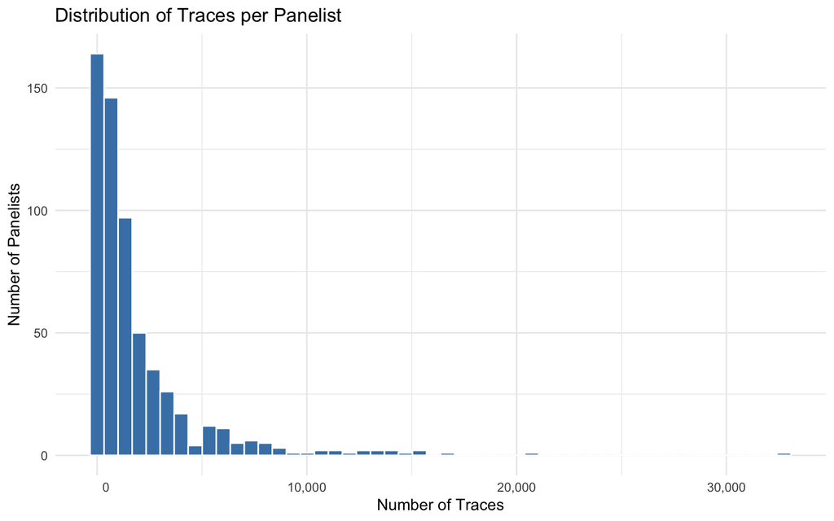

```r
# Distribution of traces per panelist
traces_per_user <- wt_data %>%
  count(panelist_id, name = "traces")

ggplot(traces_per_user, aes(x = traces)) +
  geom_histogram(bins = 50, fill = "steelblue", color = "white") +
  scale_x_continuous(labels = function(x) format(x, big.mark = ",", scientific = FALSE)) +
  labs(
    title = "Distribution of Traces per Panelist",
    x = "Number of Traces",
    y = "Number of Panelists"
  ) +
  theme_minimal()
```

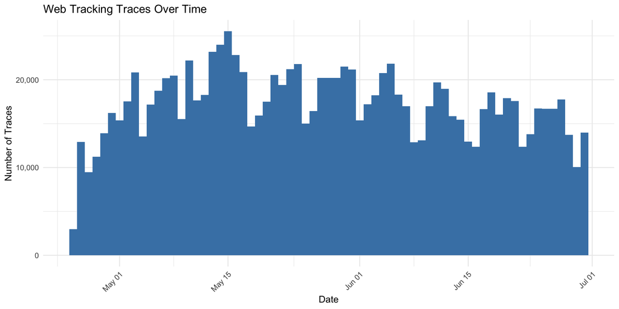

```r
# Traces over time (daily counts)
traces_over_time <- wt_data %>%
  count(date, name = "traces")

ggplot(traces_over_time, aes(x = date, y = traces)) +
  geom_col(fill = "steelblue", width = 1) +
  scale_y_continuous(labels = function(x) format(x, big.mark = ",", scientific = FALSE)) +
  labs(
    title = "Web Tracking Traces Over Time",
    x = "Date",
    y = "Number of Traces"
  ) +
  theme_minimal() +
  theme(axis.text.x = element_text(angle = 45, hjust = 1))
```

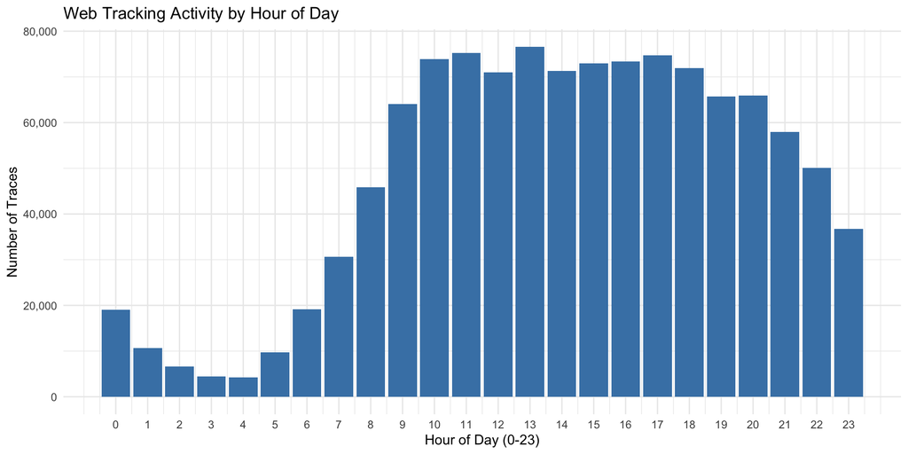

```r
# Traces by hour of day
traces_by_hour <- wt_data %>%
  mutate(hour = as.numeric(format(timestamp, "%H"))) %>%
  count(hour, name = "traces")

ggplot(traces_by_hour, aes(x = hour, y = traces)) +
  geom_col(fill = "steelblue") +
  scale_x_continuous(breaks = 0:23) +
  scale_y_continuous(labels = function(x) format(x, big.mark = ",", scientific = FALSE)) +
  labs(
    title = "Web Tracking Activity by Hour of Day",
    x = "Hour of Day (0-23)",
    y = "Number of Traces"
  ) +
  theme_minimal()
```

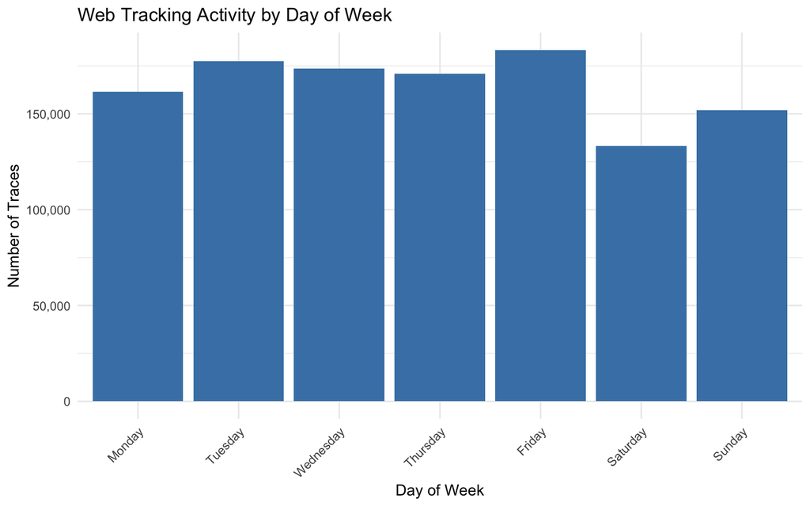

```r
# Traces by day of week
traces_by_weekday <- wt_data %>%
  mutate(
    weekday = weekdays(timestamp),
    weekday = factor(weekday,
                     levels = c("Monday", "Tuesday", "Wednesday",
                               "Thursday", "Friday", "Saturday", "Sunday"))
  ) %>%
  count(weekday, name = "traces")

ggplot(traces_by_weekday, aes(x = weekday, y = traces)) +
  geom_col(fill = "steelblue") +
  scale_y_continuous(labels = function(x) format(x, big.mark = ",", scientific = FALSE)) +
  labs(
    title = "Web Tracking Activity by Day of Week",
    x = "Day of Week",
    y = "Number of Traces"
  ) +
  theme_minimal() +
  theme(axis.text.x = element_text(angle = 45, hjust = 1))
```

The data contains not only full URLs but also entries that are just domains or privacy placeholders. This is common in web tracking data due to privacy settings and browser behavior. Understanding this heterogeneity is crucial for preprocessing and analysis. Let’s categorize the URLs into types and see how many traces fall into each category. This will help us understand the composition of our dataset and inform our parsing and classification strategies. We’ll also show sample URLs from each type to illustrate the differences.

```r
# Annotate URL type (3 categories)
wt_data <- wt_data %>%
  mutate(
    url_type = case_when(
      url %in% c("blacked_out", "full_deny") ~ "Privacy placeholder",
      str_detect(url, "^https?://") | str_detect(url, "/") ~ "Full URL",
      TRUE ~ "Domain only"
    )
  )

# Show URL type distribution
cat("=== URL Type Distribution ===\n")
wt_data %>%
  count(url_type, sort = TRUE) %>%
  mutate(
    percentage = paste0(round(n / sum(n) * 100, 1), "%")
  ) %>%
  print()

# Show sample URLs from each type
cat("\n=== Sample URLs by Type ===\n")
wt_data %>%
  group_by(url_type) %>%
  slice_sample(n = 3) %>%
  select(url_type, url) %>%
  ungroup() %>%
  arrange(url_type) %>%
  print(n = 15)
```

```
## === URL Type Distribution ===
## # A tibble: 3 × 3
##   url_type                 n percentage
##   <chr>                <int> <chr>
## 1 Full URL            467346 40.6%
## 2 Privacy placeholder 414501 36%
## 3 Domain only         270011 23.4%
##
## === Sample URLs by Type ===
## # A tibble: 9 × 2
##   url_type            url
##   <chr>               <chr>
## 1 Domain only         www.google.com
## 2 Domain only         www.youtube.com
## 3 Domain only         www.bahn.de
## 4 Full URL            https://www.musiktest24.de/
## 5 Full URL            https://ergoquest18.com/
## 6 Full URL            https://www.youtube.com/
## 7 Privacy placeholder blacked_out
## 8 Privacy placeholder blacked_out
## 9 Privacy placeholder blacked_out
```

## URL anatomy and parsing

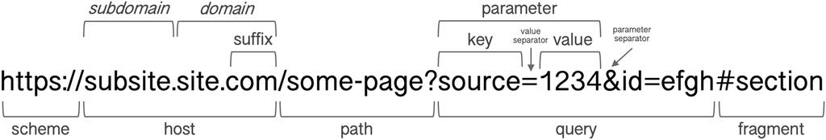

Source: https://journals.sagepub.com/doi/10.1177/08944393241227868#fig2-08944393241227868

Because the data contains only the hostname / domain for some visits, we’ll need to add a protocol to parse the URLs properly. This is a common issue with web tracking data where some entries are just domains without protocol or path for privacy reasons. Therefore, we want to add `https://` to all entries in the `url` column to ensure consistent parsing. This way, we can use URL parsing functions that expect a full URL format.

```r
# Add http:// protocol to URLs that don't have one for consistent parsing
# Skip privacy placeholders and special browser URLs

wt_data <- wt_data %>%
  mutate(
    url = case_when(
      # Keep privacy placeholders as is
      url %in% c("blacked_out", "full_deny") ~ url,
      # Already has a protocol (http://, https://, chrome://, about:, etc.) - keep as is
      str_detect(url, "^[a-z][a-z0-9+.-]*:") ~ url,
      # Add http:// to everything else (domain-only URLs)
      TRUE ~ paste0("https://", url)
    )
  )
```

Now, we can begin dissecting the URLs into their components. While we could use manual string manipulation with regex and tidyverse functions, we’ll primarily rely on webtrackR’s built-in URL parsing functions for robustness and ease of use. These functions can handle edge cases and inconsistencies in the data more effectively than manual approaches.

```r
# Using adaR to parse URL components
# adaR provides individual extraction functions and a comprehensive parser

# Get protocol (scheme)
cat("=== Top 20 Protocols ===\n")
wt_data %>%
  mutate(protocol = ada_get_protocol(url)) %>%
  count(protocol, sort = TRUE) %>%
  head(20) %>%
  print()

# Get host (domain + port)
cat("\n=== Top 20 Hosts ===\n")
wt_data %>%
  mutate(host = ada_get_host(url)) %>%
  count(host, sort = TRUE) %>%
  head(20) %>%
  print()
```

```
## === Top 20 Protocols ===
## # A tibble: 4 × 2
##   protocol      n
##   <chr>     <int>
## 1 https:   731567
## 2 <NA>     414501
## 3 chrome:    4698
## 4 about:     1092
##
## === Top 20 Hosts ===
## # A tibble: 20 × 2
##    host                      n
##    <chr>                 <int>
##  1 <NA>                 414501
##  2 www.google.com        67237
```

[output cut: 18 more lines]

```r
# OR: Parse all components at once with ada_url_parse()
cat("\n=== Sample of Parsed URL Components ===\n")
url_components <- ada_url_parse(head(wt_data$url, 50))
print(url_components |> filter(href!='blacked_out' & href!='full_deny'))

cat("\nColumns returned by ada_url_parse():\n")
cat(paste(names(url_components), collapse = ", "), "\n")
```

```
##
## === Sample of Parsed URL Components ===
##                                       href protocol username password
## 1                  https://www.ecosia.org/   https:
## 2                   https://deref-gmx.net/   https:
## 3                   https://deref-gmx.net/   https:
## 4                   https://deref-gmx.net/   https:
## 5                https://www.heypiggy.com/   https:
## 6                  https://puls.gesis.org/   https:
## 7                     https://www.gmx.net/   https:
## 8                  https://puls.gesis.org/   https:
## 9                  https://puls.gesis.org/   https:
## 10                 https://puls.gesis.org/   https:
## 11                    https://www.gmx.net/   https:
## 12                    https://www.gmx.net/   https:
```

[output cut: 26 more lines]

We can also use `adaR` to check and modify URLs. For more information, see the [adaR documentation](https://gesistsa.github.io/adaR/).

You can also use the `webtrackR` package to extract specific components. The package automatically takes care of missing protocols and then calls `adaR` under the hood.

```r
# Using webtrackR to extract URL components
# webtrackR adds new columns to the dataset and returns the modified data frame

# Before using webtrackR functions, we need to convert our data frame to a webtrackR dataset with appropriate timestamp parsing and variable names.

wtr_data <- wt_data %>%
    select(-timestamp) %>% # Remove previously parsed timestamp to avoid confusion
      as.wt_dt(
          timestamp_format = "%Y-%m-%d %H:%M:%OS",
          tz = "UTC",
          varnames = c(panelist_id = "panelist_id", url = "url", timestamp = "start_time")
        )

# Extract host (automatically handles missing protocols via adaR)
wtr_data <- extract_host(wtr_data, varname = "url")

# Extract domain (top-level domain)
wtr_data <- extract_domain(wtr_data, varname = "url")

# Extract path
wtr_data <- extract_path(wtr_data, varname = "url")
```

```r
# Show results
cat("=== Top 20 Domains ===\n")
wtr_data %>%
  count(domain, sort = TRUE) %>%
  head(20) %>%
  print()

cat("\n=== Sample of Extracted Components ===\n")
wtr_data %>%
  select(url, host, domain) %>%
  filter(!is.na(domain)) %>%
  slice_sample(n = 10) %>%
  print()
```

```
## === Top 20 Domains ===
##                domain      n
##                <char>  <int>
##  1:              <NA> 420339
##  2:        google.com  84030
##  3:       youtube.com  33911
##  4:         amazon.de  27756
##  5:          bing.com  21793
##  6:         google.de  17922
##  7:  kleinanzeigen.de  14903
##  8:           gmx.net  14597
##  9:      facebook.com  13676
## 10:            web.de  11843
## 11:     wikipedia.org  11085
## 12:           ebay.de   9531
```

[output cut: 36 more lines]

Note: webtrackR’s extract_domain() returns the ‘top private domain’, e.g., ‘mysite.blogspot.com’ not ‘blogspot.com’. For more information take a look at the [webtrackR documentation](https://gesistsa.github.io/webtrackR/reference/extract_domain.html#details).

An added benefit of using `webtrackR` is that it allows us to call `summary` on the dataset to get a quick overview of the variables and their distributions. This is a useful way to check that our parsing worked as expected and to understand the composition of our data.

```r
# Show summary of webtrackR dataset
cat("=== Summary of webtrackR Dataset ===\n")
summary(wtr_data)
```

```
## === Summary of webtrackR Dataset ===
##
##  ==== Overview ====
##
## panelists:  600
## time window:  2024-04-25 13:42:48.182  -  2024-06-30 23:59:50.813
##
## [✖] duration
## [✔] domain
## [✖] type
##
##
##
##  ====== DATA ======
##
##  panelist_id          timestamp                          url
##  Length:1151858     Min.   :2024-04-25 13:42:48.18   Length:1151858
##  Class :character   1st Qu.:2024-05-13 10:30:21.38   Class :character
##  Mode  :character   Median :2024-05-27 17:34:16.82   Mode  :character
##                     Mean   :2024-05-28 08:34:01.50
##                     3rd Qu.:2024-06-12 12:35:13.09
##                     Max.   :2024-06-30 23:59:50.80
##       date              url_type             host              domain
##  Min.   :2024-04-25   Length:1151858     Length:1151858     Length:1151858
##  1st Qu.:2024-05-13   Class :character   Class :character   Class :character
##  Median :2024-05-27   Mode  :character   Mode  :character   Mode  :character
##  Mean   :2024-05-27
##  3rd Qu.:2024-06-12
##  Max.   :2024-06-30
##      path
##  Length:1151858
##  Class :character
##  Mode  :character
##
##
##
```